# week_2_Practical_Machine_Learning_caret_package

# The Caret Package

```r
library(caret)
library(kernlab)
data(spam)
```

now we will split the data into training set(75%) and testing set(25%)

```r
inTrain <- createDataPartition(y=spam$type, p=0.75, list = FALSE)
training <- spam[inTrain,]
testing <-  spam[-inTrain,]
```

total number of instances

```r
dim(spam)
```

```
## [1] 4601   58
```

after spliting number of instances are

```r
dim(training)
```

```
## [1] 3451   58
```

```r
dim(testing)
```

```
## [1] 1150   58
```

dot(.) means use all the prdictor to predit the type

```r
set.seed(32343)
modelFit <-  train(type ~ . , data = training , method = "glm")
```

[output not shown]

```r
modelFit
```

```
## Generalized Linear Model
##
## 3451 samples
##   57 predictor
##    2 classes: 'nonspam', 'spam'
##
## No pre-processing
## Resampling: Bootstrapped (25 reps)
## Summary of sample sizes: 3451, 3451, 3451, 3451, 3451, 3451, ...
## Resampling results:
##
##   Accuracy   Kappa
##   0.9220599  0.8360448
```

so it is using 57 prdictor to predict whcih class

after fit the model we can look at the model

```r
modelFit$finalModel
```

```
##
## Call:  NULL
##
## Coefficients:
##       (Intercept)               make            address                all
##        -1.468e+00         -3.184e-01         -1.720e-01          1.175e-01
##             num3d                our               over             remove
##         3.723e+00          4.270e-01          6.821e-01          2.213e+00
##          internet              order               mail            receive
##         5.107e-01          7.752e-01          7.616e-02         -4.414e-01
##              will             people             report          addresses
##        -1.222e-01          1.258e-01          7.076e-02          8.229e-01
##              free           business              email                you
##         1.217e+00          7.127e-01          1.547e-01          7.241e-02
##            credit               your               font             num000
##         1.122e+00          2.785e-01          2.266e-01          2.993e+00
##             money                 hp                hpl             george
##         6.268e-01         -2.248e+00         -1.157e+00         -1.130e+01
##            num650                lab               labs             telnet
##         4.292e-01         -3.747e+00          1.476e-02         -3.335e+00
##            num857               data             num415              num85
##         3.571e+00         -9.109e-01          6.161e-01         -2.882e+00
##        technology            num1999              parts                 pm
##         1.115e+00          1.293e-01          1.067e+00         -1.117e+00
##            direct                 cs            meeting           original
##        -1.911e-01         -4.431e+01         -2.501e+00         -1.177e+00
##           project                 re                edu              table
##        -1.777e+00         -7.545e-01         -1.349e+00         -2.997e+00
##        conference      charSemicolon   charRoundbracket  charSquarebracket
##        -3.559e+00         -1.220e+00         -1.822e-01         -1.033e+00
##   charExclamation         charDollar           charHash         capitalAve
##         2.928e-01          4.553e+00          1.822e+00          2.435e-03
##       capitalLong       capitalTotal
##         9.939e-03          6.764e-04
##
## Degrees of Freedom: 3450 Total (i.e. Null);  3393 Residual
## Null Deviance:       4628
## Residual Deviance: 1356  AIC: 1472
```

after FITING the model we can predict on new data that is TESTING data

```r
prediction <- predict(modelFit, newdata = testing)
prediction
```

```
##    [1] spam    spam    spam    spam    spam    nonspam spam    spam    spam
##   [10] spam    spam    spam    nonspam spam    spam    spam    spam    spam
##   [19] spam    spam    spam    spam    spam    spam    spam    nonspam spam
##   [28] spam    spam    spam    spam    spam    spam    spam    spam    spam
##   [37] spam    spam    spam    spam    nonspam spam    spam    spam    nonspam
##   [46] spam    spam    spam    spam    spam    spam    spam    spam    spam
##   [55] nonspam spam    spam    spam    spam    spam    spam    spam    spam
##   [64] spam    spam    spam    spam    nonspam spam    nonspam spam    spam
##   [73] spam    spam    spam    spam    spam    spam    spam    spam    nonspam
##   [82] spam    spam    spam    spam    spam    spam    nonspam spam    spam
##   [91] spam    spam    spam    spam    spam    spam    spam    spam    spam
##  [100] spam    nonspam spam    spam    spam    spam    nonspam spam    spam
##  [109] spam    spam    spam    spam    nonspam spam    spam    spam    spam
##  [118] spam    nonspam spam    spam    spam    spam    spam    spam    spam
##  [127] spam    spam    spam    spam    spam    spam    spam    spam    spam
```

[output cut: 114 more lines]

now create a CONFUSION matrix

```r
confusionMatrix(prediction,testing$type)
```

```
## Confusion Matrix and Statistics
##
##           Reference
## Prediction nonspam spam
##    nonspam     665   47
##    spam         32  406
##
##                Accuracy : 0.9313
##                  95% CI : (0.9151, 0.9452)
##     No Information Rate : 0.6061
##     P-Value [Acc > NIR] : <2e-16
##
##                   Kappa : 0.8553
##
##  Mcnemar's Test P-Value : 0.1152
##
##             Sensitivity : 0.9541
##             Specificity : 0.8962
##          Pos Pred Value : 0.9340
##          Neg Pred Value : 0.9269
##              Prevalence : 0.6061
##          Detection Rate : 0.5783
##    Detection Prevalence : 0.6191
##       Balanced Accuracy : 0.9252
##
##        'Positive' Class : nonspam
##
```

so it is showing that our model’s accuracy is 93%

# Data Slicing

one way is inTrain <- createDataPartition(y=spam$type, p=0.75, list = FALSE) training <- spam[inTrain,] testing <- spam[-inTrain,]

second way is K-Fold

```r
set.seed(32323)
folds <- createFolds( y = spam$type , k= 10 , list = TRUE , returnTrain = TRUE)
sapply(folds, length)
```

```
## Fold01 Fold02 Fold03 Fold04 Fold05 Fold06 Fold07 Fold08 Fold09 Fold10
##   4140   4142   4141   4140   4141   4141   4142   4141   4141   4140
```

returnTrain = TRUE so it will return the training set

this will check in 1st fold which elements are included

```r
folds[[1]][1:10]
```

```
##  [1]  1  2  4  5  6  7  8  9 10 11
```

so change the value of returnTrain = FLASE

```r
set.seed(32323)
folds <- createFolds( y = spam$type , k= 10 , list = TRUE , returnTrain = FALSE)
sapply(folds, length)
```

```
## Fold01 Fold02 Fold03 Fold04 Fold05 Fold06 Fold07 Fold08 Fold09 Fold10
##    461    459    460    461    460    460    459    460    460    461
```

so it will return the test set only

and look at the testing sets 1st fold element

```r
folds[[1]][1:10]
```

```
##  [1]  3 19 33 38 44 51 66 67 72 83
```

### resapmling

If you want to do resampling or bootstrapping instead of cross validation

```r
set.seed(32324)
folds <-  createResample(y = spam$type , times = 10, list = TRUE)
sapply(folds, length)
```

```
## Resample01 Resample02 Resample03 Resample04 Resample05 Resample06 Resample07
##       4601       4601       4601       4601       4601       4601       4601
## Resample08 Resample09 Resample10
##       4601       4601       4601
```

this will repeat some elements(instances) because it is re-sampling from the replacment value

```r
folds[[1]][1:10]
```

```
##  [1]  1  2  2  3  3  4  5  6 11 12
```

for analyzing forecasting then you neeed TIME SLICING

```r
set.seed(32324)
#creating a vector of 1000 value
tme <-  1:1000
folds <-createTimeSlices( y = tme , initialWindow = 20 , horizon = 10)
names(folds)
```

```
## [1] "train" "test"
```

```r
folds$train[[1]]
```

```
##  [1]  1  2  3  4  5  6  7  8  9 10 11 12 13 14 15 16 17 18 19 20
```

```r
folds$test[[1]]
```

```
##  [1] 21 22 23 24 25 26 27 28 29 30
```

# Training Options

in OneNote

# Plotting Predictors

ISLR contain Wage dataset

```r
library(ISLR)
library(ggplot2)
library(caret)
```

```r
data(Wage)
summary(Wage)
```

```
##       year           age                     maritl           race
##  Min.   :2003   Min.   :18.00   1. Never Married: 648   1. White:2480
##  1st Qu.:2004   1st Qu.:33.75   2. Married      :2074   2. Black: 293
##  Median :2006   Median :42.00   3. Widowed      :  19   3. Asian: 190
##  Mean   :2006   Mean   :42.41   4. Divorced     : 204   4. Other:  37
##  3rd Qu.:2008   3rd Qu.:51.00   5. Separated    :  55
##  Max.   :2009   Max.   :80.00
##
##               education                     region               jobclass
##  1. < HS Grad      :268   2. Middle Atlantic   :3000   1. Industrial :1544
##  2. HS Grad        :971   1. New England       :   0   2. Information:1456
##  3. Some College   :650   3. East North Central:   0
##  4. College Grad   :685   4. West North Central:   0
##  5. Advanced Degree:426   5. South Atlantic    :   0
##                           6. East South Central:   0
##                           (Other)              :   0
##             health      health_ins      logwage           wage
##  1. <=Good     : 858   1. Yes:2083   Min.   :3.000   Min.   : 20.09
##  2. >=Very Good:2142   2. No : 917   1st Qu.:4.447   1st Qu.: 85.38
##                                      Median :4.653   Median :104.92
##                                      Mean   :4.654   Mean   :111.70
##                                      3rd Qu.:4.857   3rd Qu.:128.68
##                                      Max.   :5.763   Max.   :318.34
##
```

now we will split our data 70% to trainig and 30% to testing

```r
iTrain <- createDataPartition( y = Wage$wage , p = 0.7 , list = FALSE)
training <- Wage[iTrain,]
testing <- Wage[-iTrain,]
dim(training);dim(testing)
```

```
## [1] 2102   11
```

```
## [1] 898  11
```

featurePlot

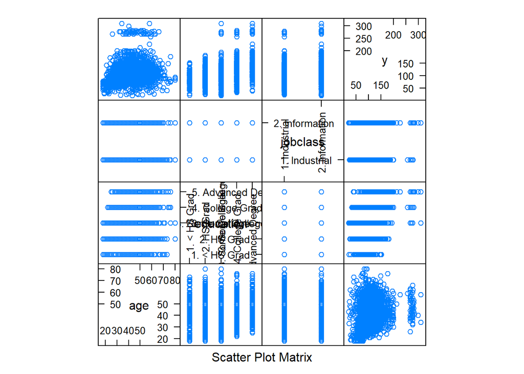

```r
featurePlot(x = training[,c("age","education","jobclass")],
            y = training$wage ,
            plot = "pairs" )
```

qplot for age vs wage from ggplot2

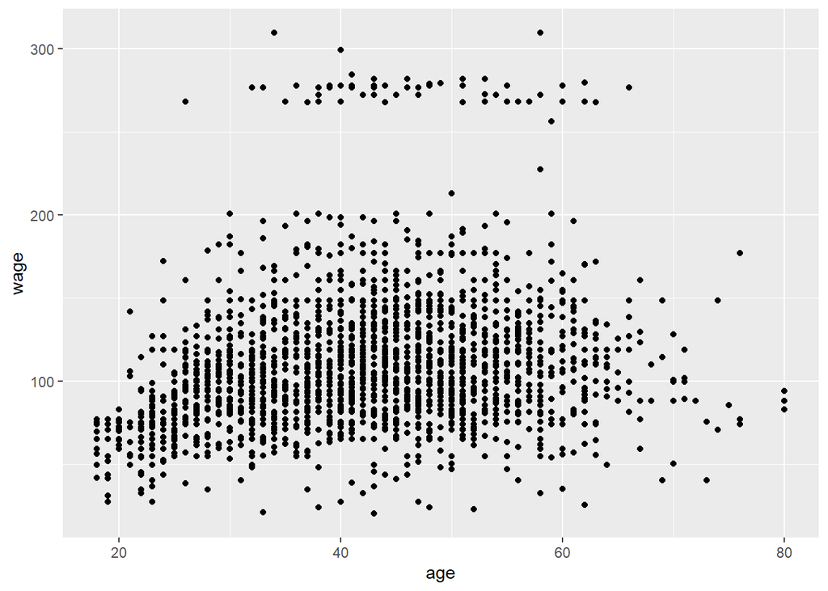

```r
qplot(age, wage , data= training )
```

there are two cluster so to identify that what is the realtionship we will plot with color

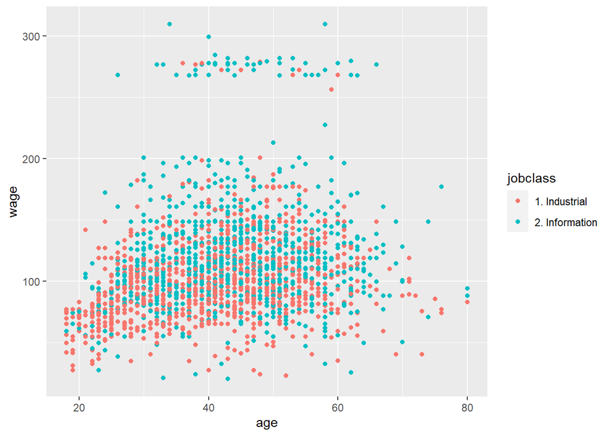

```r
qplot(age, wage ,color = jobclass, data= training )
```

now we will apply regression line to see the relationship

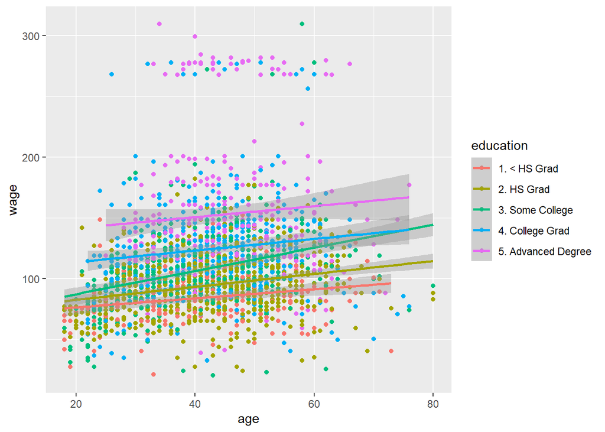

```r
qq <- qplot(age, wage , color = education , data= training )
qq + geom_smooth(method = "lm" , formula = y ~ x )
```

```r
library("Hmisc")
cutWage <- cut2(training$wage , g = 3)
table(cutWage)
```

```
## cutWage
## [ 20.1, 91.7) [ 91.7,119.0) [119.0,309.6]
##           701           744           657
```

now we can use that groups to plot

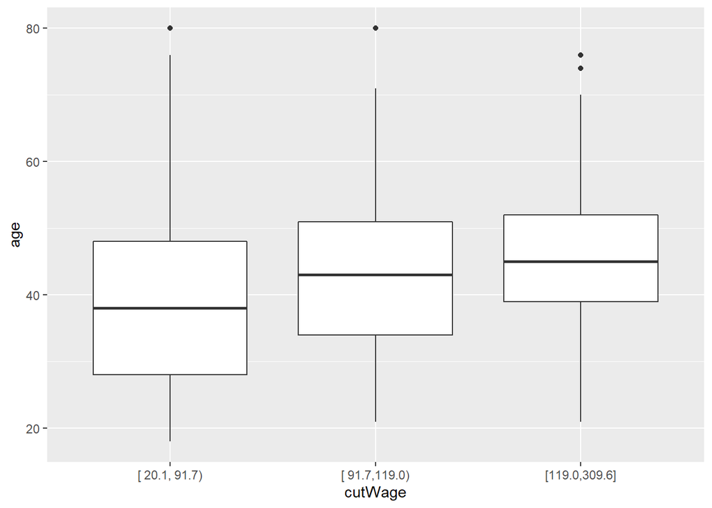

```r
p1 <- qplot( cutWage , age  , data = training , fil = cutWage  , geom = c("boxplot"))
p1
```

for more clarity we will plot dots (jitter ) above the box plot

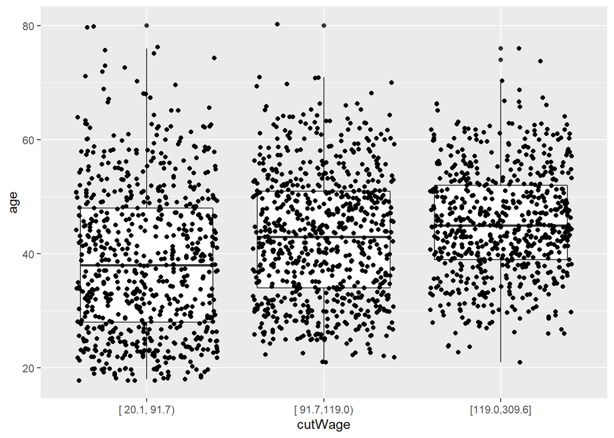

```r
p2 <- qplot( cutWage , age  , data = training , fil = cutWage  , geom = c("boxplot","jitter"))
p2
```

we can use cut to see the tables aslo

```r
t1 <- table(cutWage , training$jobclass)
t1
```

```
##
## cutWage         1. Industrial 2. Information
##   [ 20.1, 91.7)           456            245
##   [ 91.7,119.0)           385            359
##   [119.0,309.6]           251            406
```

```r
prop.table(t1,1)
```

```
##
## cutWage         1. Industrial 2. Information
##   [ 20.1, 91.7)     0.6504993      0.3495007
##   [ 91.7,119.0)     0.5174731      0.4825269
##   [119.0,309.6]     0.3820396      0.6179604
```

pass 1 to see proportion of each row pass 2 to see proportion of each column

now plot the density plot

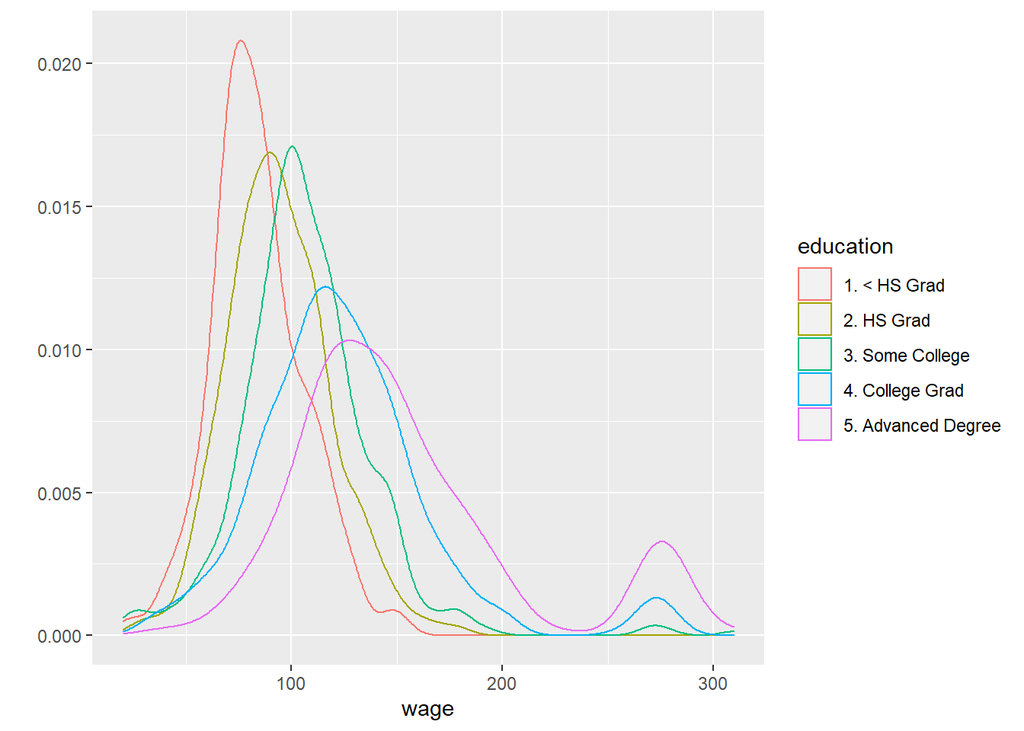

```r
qplot(wage , colour = education , data = training , geom = "density")
```

# Processing

```r
library(kernlab)
library(caret)
data(spam)
```

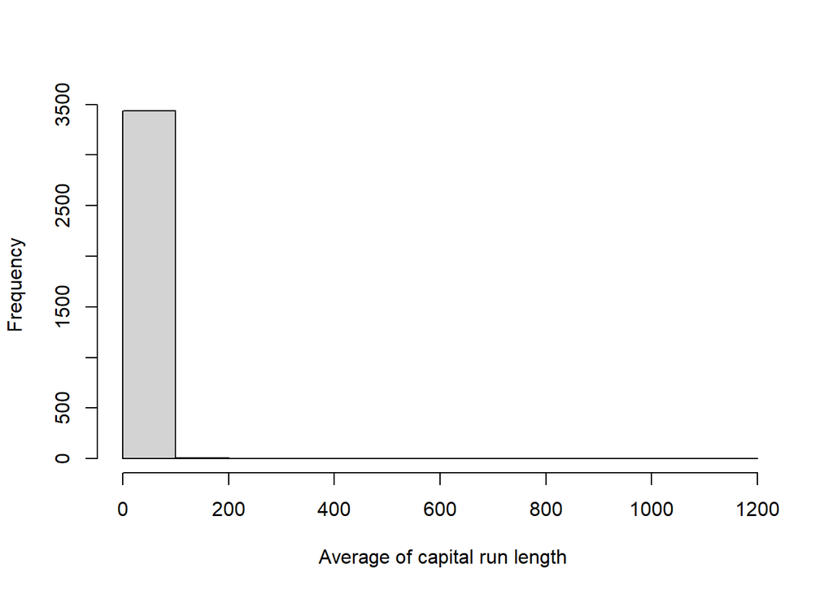

```r
inTrain <- createDataPartition(y=spam$type, p=0.75, list = FALSE)
training <- spam[inTrain,]
testing <-  spam[-inTrain,]
hist(training$capitalAve , main = "" , xlab = " Average of capital run length")
```

```r
mean(training$capitalAve)
```

```
## [1] 5.219416
```

```r
sd(training$capitalAve)
```

```
## [1] 31.88827
```

SD is to high so we will apply STANDARDIZTION

```r
trainCapAve <-  training$capitalAve
trainCapAveS <- (trainCapAve - mean(trainCapAve))/sd(trainCapAve)
mean(trainCapAveS)
```

```
## [1] -9.722428e-18
```

```r
sd(trainCapAveS)
```

```
## [1] 1
```

we have to do it for test set also but we have to use the mean from the training set, and the standard deviation from the training set, to standardize the testing set values.

```r
testCapAve <-  testing$capitalAve
testCapAveS <- (testCapAve - mean(trainCapAve))/sd(trainCapAve)
mean(testCapAveS)
```

```
## [1] -0.003500643
```

```r
sd(testCapAveS)
```

```
## [1] 0.9803479
```

we can perfrom standardizing using preProcessing function from caret

```r
preObj <-  preProcess(training[,-58], method = c("center","scale"))
trainCapAveS <-  predict(preObj , training[,-58])$capitalAve
mean(trainCapAveS)
```

```
## [1] -9.722428e-18
```

```r
sd(trainCapAveS)
```

```
## [1] 1
```

Now we will apply preProcessing to test set we will apply same object which we apply for train set

```r
testCapAveS <- predict(preObj, testing[,-58])$capitalAve
mean(testCapAveS)
```

```
## [1] -0.003500643
```

```r
sd(testCapAveS)
```

```
## [1] 0.9803479
```

We can preProcessing as an argument also

```r
set.seed(32324)
modelFit <-  train(type ~ . , data = training , preProcess = c("center","scale"), method = "glm")
```

[output not shown]

```r
modelFit
```

```
## Generalized Linear Model
##
## 3451 samples
##   57 predictor
##    2 classes: 'nonspam', 'spam'
##
## Pre-processing: centered (57), scaled (57)
## Resampling: Bootstrapped (25 reps)
## Summary of sample sizes: 3451, 3451, 3451, 3451, 3451, 3451, ...
## Resampling results:
##
##   Accuracy   Kappa
##   0.9214438  0.8345421
```

standardizing using BOX COX transformation

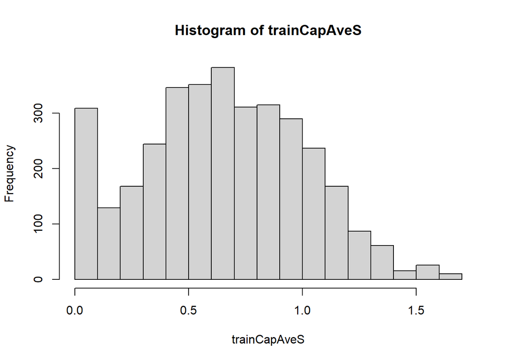

```r
preObj <- preProcess(training[,-58] , method = c("BoxCox"))
trainCapAveS <-  predict(preObj, training[,-58])$capitalAve
hist(trainCapAveS)
```

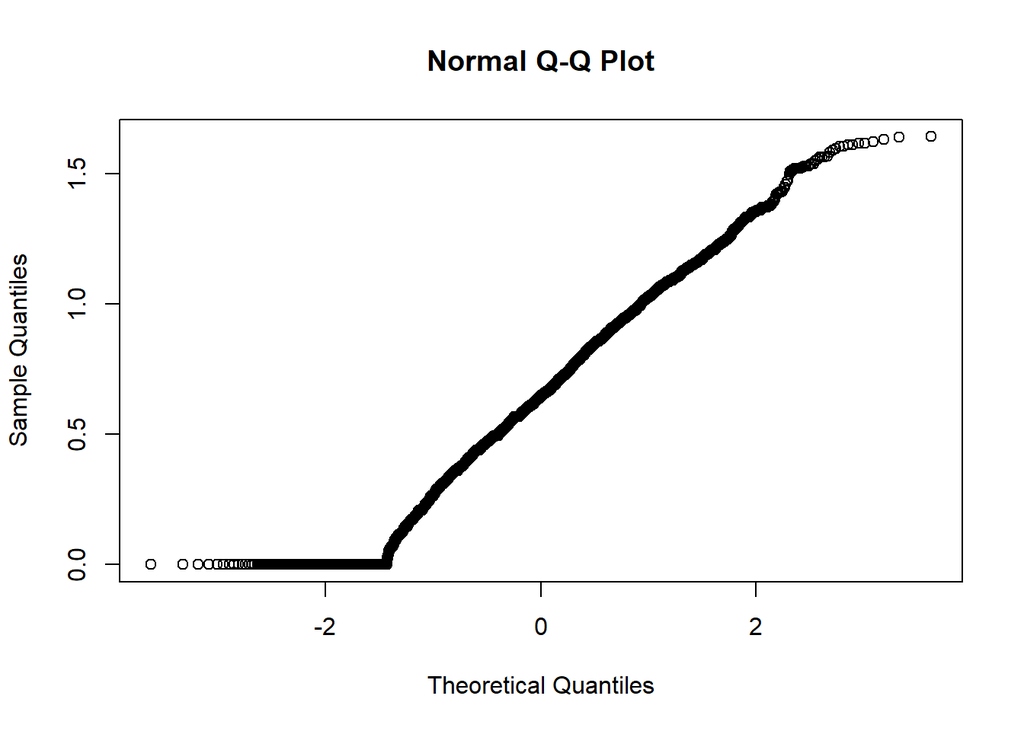

```r
qqnorm(trainCapAveS)
```

### imputing data

If you have some missing data you can impute them using KNN

```r
#we select the capitalAve
training$capAve <- training$capitalAve
#and generate random value and set equal to NA
selectNA <-  rbinom(dim(training)[1] , size = 1 ,prob = 0.05)==1
#so capAve is exactly like capitalAve but it has a subset of values that are missing
training$capAve[selectNA] <- NA



#so now we will handle this missing values
#impute ans standardize
preObj <-  preProcess(training[,-58], method = "knnImpute")
capAve <-  predict(preObj,training[,-58])$capAve

#standardize true values
capAveTruth <- training$capitalAve
capAveTruth <-  (capAveTruth - mean(capAveTruth))/sd(capAveTruth)
```

# Covariant Creation

```r
iTrain <- createDataPartition( y = Wage$wage , p = 0.7 , list = FALSE)
training <- Wage[iTrain,]
testing <- Wage[-iTrain,]
dim(training);dim(testing)
```

```
## [1] 2102   11
```

```
## [1] 898  11
```

```r
table(training$jobclass)
```

```
##
##  1. Industrial 2. Information
##           1082           1020
```

it has qualitative variable and they are hard to predict so we will convert it to qualitative variable

```r
dummies <-  dummyVars(wage ~ jobclass , data = training)
prediction <-  predict(dummies , newdata = training)
head(prediction)
```

```
##        jobclass.1. Industrial jobclass.2. Information
## 231655                      1                       0
## 86582                       0                       1
## 161300                      1                       0
## 155159                      0                       1
## 376662                      0                       1
## 450601                      1                       0
```

So, 1 for Industrial and 2 for Information job

If some variable has no meaning then we will remove them (( The variable which are not likely to predict. So remove those PREDICTOR ))

```r
nsv <-  nearZeroVar(training , saveMetrics = TRUE)
nsv
```

```
##            freqRatio percentUnique zeroVar   nzv
## year        1.049708    0.33301618   FALSE FALSE
## age         1.040541    2.90199810   FALSE FALSE
## maritl      3.042194    0.23786870   FALSE FALSE
## race        8.470874    0.19029496   FALSE FALSE
## education   1.443064    0.23786870   FALSE FALSE
## region      0.000000    0.04757374    TRUE  TRUE
## jobclass    1.060784    0.09514748   FALSE FALSE
## health      2.532773    0.09514748   FALSE FALSE
## health_ins  2.325949    0.09514748   FALSE FALSE
## logwage     1.112500   18.79162702   FALSE FALSE
## wage        1.112500   18.79162702   FALSE FALSE
```

region has nsv TRUE so wee will discard it

```r
library(splines)
bsBias <- bs(training$age , df = 3)
bsBias
```

```
##                   1            2            3
##    [1,] 0.000000000 0.0000000000 0.000000e+00
##    [2,] 0.236850055 0.0253767916 9.063140e-04
##    [3,] 0.416337988 0.3211750193 8.258786e-02
##    [4,] 0.430813836 0.2910904300 6.556091e-02
##    [5,] 0.306334128 0.4241549461 1.957638e-01
##    [6,] 0.424154946 0.3063341278 7.374710e-02
##    [7,] 0.377630828 0.0906313987 7.250512e-03
##    [8,] 0.440355309 0.2596967205 5.105149e-02
##    [9,] 0.416337988 0.3211750193 8.258786e-02
##   [10,] 0.426168977 0.1482326877 1.718640e-02
##   [11,] 0.306334128 0.4241549461 1.957638e-01
##   [12,] 0.362525595 0.3866939680 1.374912e-01
##   [13,] 0.275519452 0.4362391326 2.302373e-01
##   [14,] 0.442218287 0.1953987782 2.877966e-02
```

[output cut: 2098 more lines]

bs() is used to to create straight line to curvy line with data

fiiting curve with splines

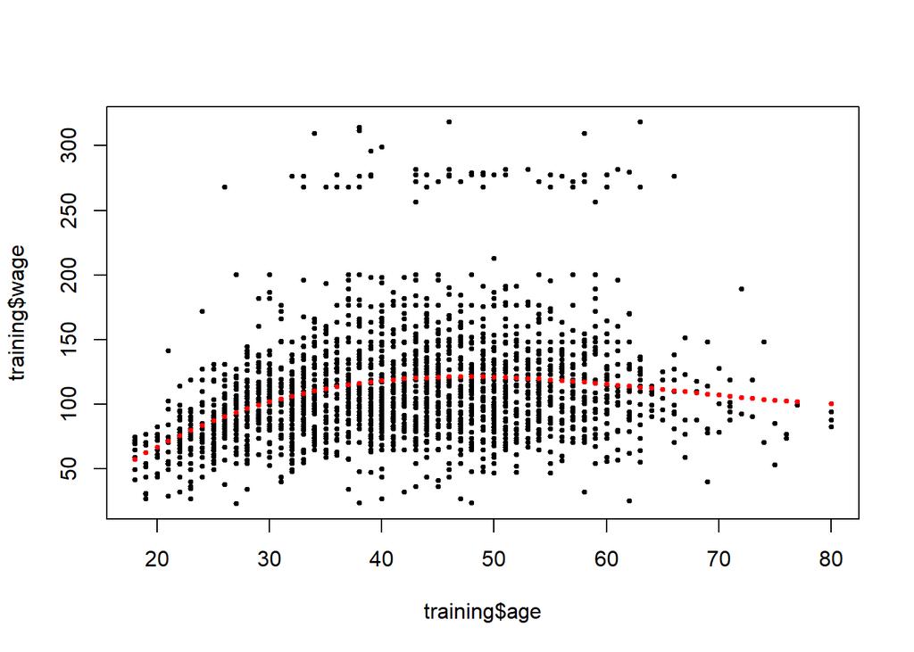

```r
#first we will create a linear model
lm1 <- lm(wage ~ bsBias , data = training)
plot(training$age , training$wage , pch=19 , cex = 0.5)
points(training$age , predict(lm1, newdata = training) , col = "red" , pch = 19 , cex = 0.5)
```

now we have to do same for test set

```r
predict(bsBias , age=testing$age)
```

```
##                   1            2            3
##    [1,] 0.000000000 0.0000000000 0.000000e+00
##    [2,] 0.236850055 0.0253767916 9.063140e-04
##    [3,] 0.416337988 0.3211750193 8.258786e-02
##    [4,] 0.430813836 0.2910904300 6.556091e-02
##    [5,] 0.306334128 0.4241549461 1.957638e-01
##    [6,] 0.424154946 0.3063341278 7.374710e-02
##    [7,] 0.377630828 0.0906313987 7.250512e-03
##    [8,] 0.440355309 0.2596967205 5.105149e-02
##    [9,] 0.416337988 0.3211750193 8.258786e-02
##   [10,] 0.426168977 0.1482326877 1.718640e-02
##   [11,] 0.306334128 0.4241549461 1.957638e-01
##   [12,] 0.362525595 0.3866939680 1.374912e-01
##   [13,] 0.275519452 0.4362391326 2.302373e-01
##   [14,] 0.442218287 0.1953987782 2.877966e-02
```

[output cut: 2098 more lines]